# Tema 11 - Aprendizaje Estadístico

Universidad de Alicante, Curso 2021/22

## Aprendizaje Estadístico o Automático

- Aprendizaje automático (*machine learning*, ML) o estadístico (*statiscal learning*): conjunto de técnicas algorítmicas para extraer información de los datos
- [Tipos principales](https://vitalflux.com/wp-content/uploads/2020/12/mind_map_machine_learning_3.jpg)
1. **Aprendizaje supervisado**: escenarios en los que para cada observación de las mediciones \(X_i\) hay una *respuesta asociada* \(Y_i\) (“supervisa” el aprendizaje)
   - Aprendemos la respuesta de casos nuevos a partir de casos previos
2. **Aprendizaje no supervisado**: no hay una respuesta asociada a las mediciones de \(X_i\) para supervisar el análisis que generará un modelo.
   - Aprendemos rasgos no medidos a partir de casos “no etiquetados”: ej. observaciones similares organizadas en grupos distintos

## Aprendizaje supervisado

- \(\small Y = f(X) + \varepsilon\): Modelo para la variable dependiente (de respuesta) en función de factores observados (predictores/características) y no observados (\(\small \varepsilon\))
  - \(f\) representa la información/relación sistemática que \(X\) (género, educación, etc.) ofrecen sobre un resultado medido \(Y\) (ej. renta)
- Objetivos: predecir casos *nuevos* y comprender qué factores afectan al resultado y cómo (¡cuidado con afirmaciones de *causalidad*!)
- **Modelo paramétrico:** supone un forma de \(f\) que depende de parámetros desconocidos, p.e., lineal \(f(x) =\beta_0 + \beta_1 x_1 + \dots + \beta_k x_k\)
- **Modelo no paramétrico:** ajustar \(f\) a los datos sin supuestos funcionales
- A mayor flexibilidad, mejor ajuste, PERO existe una disyuntiva entre precisión de la predicción e **interpretabilidad** (inferencia)

## Problemas de “regresión” y de clasificación

1.- **Regresión**: variable de respuesta cuantitativa (toma valores numéricos)

```r
library(mosaicData)
mod <- lm(volume ~ poly(avgtemp,3), data = RailTrail)
cbind(RailTrail$volume, mod$fitted, RailTrail$avgtemp) %>% head()
```

[output not shown]

2.- **Clasificación**: variable de respuesta cualitativa (toma valores en una de \(C\) categorías o clases)

```r
censo <- read_csv("data/census.csv") %>%
  mutate(income = as.integer(factor(income))-1)
logit <- glm(income ~ capital_gain, data = censo, family = "binomial")
cbind(censo$income, predict(logit, type = "response")) %>% head()
```

[output not shown]

- La predicción mejora si incluimos más variables explicativas (modelo más flexible)

## Error de predicción

- Un modelo es mejor si sus predicciones se ajusten mejor a las observaciones
- El error de predicción es \(y - \widehat{y} = f(X) - \widehat{f}(X) + \varepsilon\)
  - \(f - \widehat{f}\) = error reducible (eligiendo modelo)
  - \(\varepsilon\) = error irreducible (variables no observadas)
- La **función de pérdida (o coste)** evalúa cómo valoramos las desviaciones

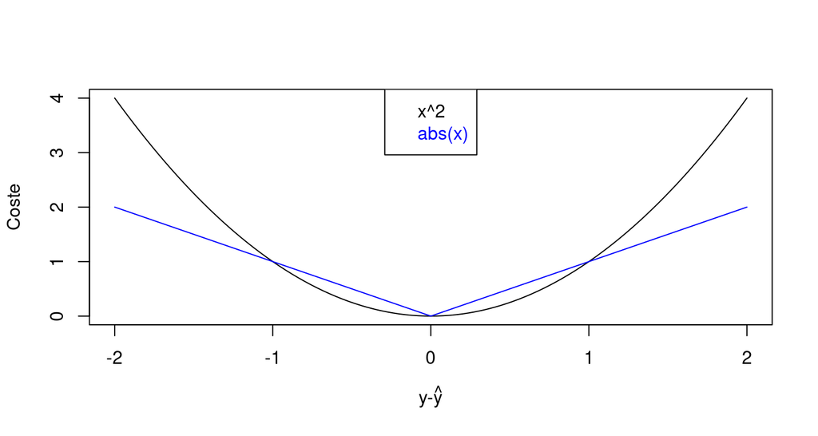

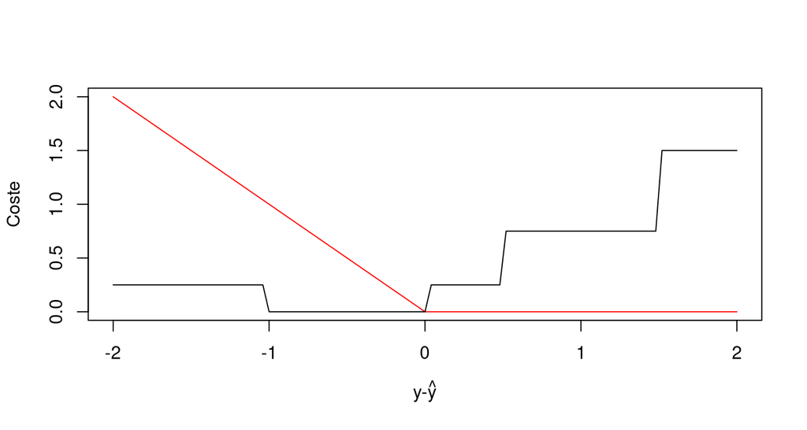

## Métricas de error de predicción (cuantitativa)

- *Mean Square Error*: \(\small MSE(y,\widehat{y})={\frac{1}{n}\sum_{i=1}^{n}\left(y-\widehat{y}\right)^2}\)
  - Error Cuadrático Medio (ECM)
  - penaliza grandes desviaciones
- *Root Mean Square Error*: \(\small RMSE(y,\widehat{y})=\sqrt{\frac{1}{n}\sum_{i=1}^{n}\left(y-\widehat{y}\right)^2}\)
  - mismas unidades que \(\small y\)
- *Mean Absolute Error*: \(\small MAE(y,\widehat{y})=\frac{1}{n}\sum_{i=1}^{n}\left|y-\widehat{y}\right|\)
- *Correlación* lineal o de rangos entre \(\small y\) y \(\small \widehat{y}\)
- *Coeficiente de determinación*, \(\small R^2\), y \(\small R^2-ajustado\)
- \(\small AIC\), \(\small BIC\), …

## Muestras de entrenamiento y de prueba

- Las métricas de error (ej., \(\small MSE\)) suelen calcularse para predicciones de los mismos datos usados para ajustar/estimar el modelo (*in-sample prediction*)
  - Esta muestra se denomina **muestra de entrenamiento** (*training sample*)
- PERO queremos saber qué tal se predicen *casos nuevos* (*out-sample prediction*)
- Esto lleva a problemas de **“overfitting”** (sobreajuste): un modelo menos flexible tendría menor error de predicción con casos nuevos
  - Los grados de libertad (número de valores en el modelo que son libres de variar) resume la *flexibilidad* de una curva.
- Debemos calcular las métricas de error con observaciones que el modelo NO ha usado antes: **muestra de prueba** (*test sample*)

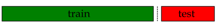

## “Overfitting”

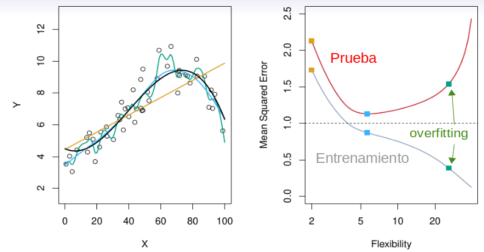

```r
RailTrail %>% ggplot(aes(x = avgtemp, y = volume)) +
  geom_point() + geom_smooth(method = 'lm', formula = y ~ poly(x,22) ) +
  coord_cartesian(ylim = c(100,750))
```

[output not shown]

## “Overfitting” (cont.)

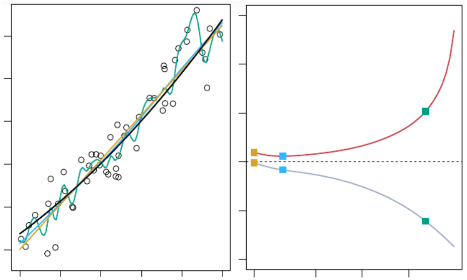

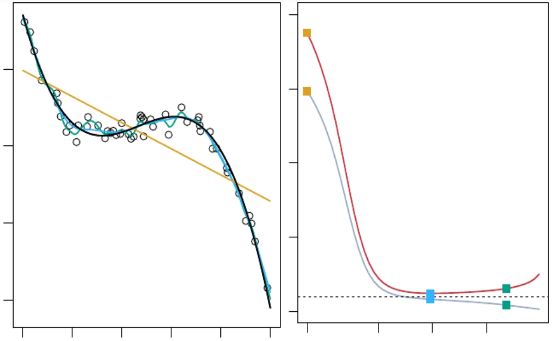

- Siempre que aumenta la flexibilidad, el MSE
  - disminuye en la muestra de entrenamiento
  - tiene forma de U en la muestra de prueba
- Nota: el MSE en entrenamiento es siempre menor que en prueba

## MSE en la muestra de prueba

\[ \small E\left[\left(y-\widehat{f}(x)\right)^2\right] = E\left[\left(f(x)-\widehat{f}(x) + \varepsilon + E\left[\widehat{f}(x)\right]-E\left[\widehat{f}(x)\right] \right)^2\right] = \]

\[ \small =\underbrace{\left[E\left(\widehat{f}(x)\right)-f(x)\right]^2}_{(1)} + \underbrace{E\left(\left[\widehat{f}(x)-E\left(\widehat{f}(x)\right)\right]^2\right)}_{(2)}+Var(\varepsilon) \]

- \(\small (1)=\left[Sesgo\left(\widehat{f}(x)\right)\right]^2\): error por supuestos erróneos en \(f\)
  - ajuste insuficiente (*underfit*) al perder relaciones relevantes entre \(X\) e \(Y\)
- \(\small (2)=Var\left(\widehat{f}(x)\right)\): sensibilidad a fluctuaciones en el entrenamiento
  - si el algoritmo modela puro ruido en entrenamiento, ajustará bien allí, pero predecirá mal casos nuevos (*overfit*)

## “Trade-off” Varianza–Sesgo

- El sesgo se reduce y la varianza aumenta con la complejidad del modelo \(\Rightarrow\) encontrar un método (ej., flexibilidad) para el ambos sean bajos

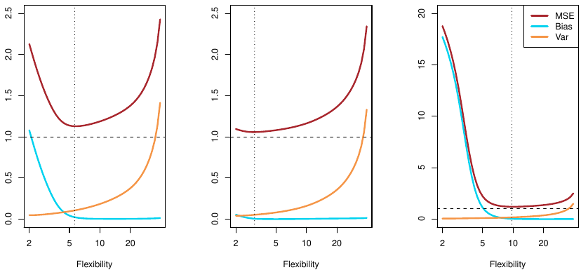

- NO es posible minimizar simultáneamente ambas fuentes de error: *memorización* (en entrenamiento) vs. *generalización* de resultados

## Medir el Error en la Clasificación

- Los modelos de clasificación NO predicen directamente la categoría, sino la *probabilidad* de que una observación pertenezca a cada categoría
- Típicamente se asigna la clase predicha como aquella con mayor probabilidad: en el caso binario, fijar un umbral de 0.5

```r
logit <- glm(income ~ capital_gain, data = censo, family = "binomial")
prob.predict <- predict(logit, type = "response")

umbral <- 0.5

cat.predict  <- if_else(prob.predict > umbral, 1, 0)
cbind(censo$income, cat.predict, prob.predict) %>% head(10)
```

[output not shown]

- Como no tiene sentido diferencia de clases (variables categóricas), NO se pueden calcular medidas como el MSE y otros relacionados

## Matriz de Confusión

- **Matriz de confusión**: tabular categorías observadas frente a las categorías predichas

| . | CLASE OBSERVADA POSITIVO (1) | CLASE OBSERVADA NEGATIVO (0) |
| --- | --- | --- |
| **CLASE PREDICHA** |  |  |
| POSITIVO (1) | Verdadero Positivo [VP] | Falso Positivo [FP] |
|  |  | (Error Tipo I) |
| NEGATIVO (0) | Falso Negativo [FN] | Verdadero Negativo [VN] |
|  | (Error Tipo II) |  |

```r
table(cat.predict, censo$income)
```

[output not shown]

## Métricas con la matriz de confusión

- **Tasa de error en la clasificación o de clasificación errónea**:

  \(\small TCE=\frac{FP+FN}{VP+FP+VN+FN} = \frac{1}{n}\sum_{i=1}^{n}I\left[y_i \neq \widehat{y}_i\right]\)
- Su complemento es la tasa de observaciones correctamente clasificadas (exactitud o *accuracy*)

  \(\small ACCUR=\frac{VP+VN}{VP+FP+VN+FN}= 1 - TCE\)
- No informativa cuando algunas clases son infrecuentes (datos *imbalanced* o desequilibrados): ej., baja TCE porque es trivial predecir la clase mayoritaria
- La **precisión** o valor de predicción positivo es la cantidad de verdaderos positivos sobre el total de positivos predichos \(\small PREC=\frac{VP}{VP+FP}\)

## Métricas con la matriz de confusión (cont.)

- La **tasa de verdaderos positivos**, **sensibilidad** o exahustividad (*recall*) es la cantidad de verdaderos positivos sobre el total de positivos observados

\[ \small TVP=SENSIT=\frac{VP}{VP+FN} \]

- La **tasa de verdaderos negativos** o *especificidad* es la cantidad de verdaderos negativos sobre el total de negativos observados

\[ \small \small TVN=ESPECIF=\frac{VN}{VN+FP} \]

- **Tasa de falsos positivos**: \(\small TFP = 1 - TVN = 1 - ESPECIF\)
- Existen varias otras medidas derivadas de las anteriores

## Curva ROC y AUC

- La **curva ROC** (“receiver operating characteristic”) representa TVP (eje y) frente a TFP (eje x) en *diferentes umbrales de clasificación*

[figure not shown]

## Curva ROC y AUC (cont.)

- AUC informa del grado de separabilidad: mayor AUC implica que el modelo es capaz de distinguir entre clases (predecir 0s y 1s correctamente)

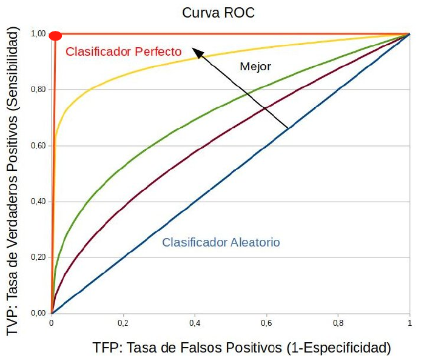

## Evaluación de Modelos: entrenamiento y prueba

- Para minimizar problemas de *underfit* y, sobre todo, de *overfit*, DEBEMOS **dividir aleatoriamente** el conjunto de datos en dos partes:

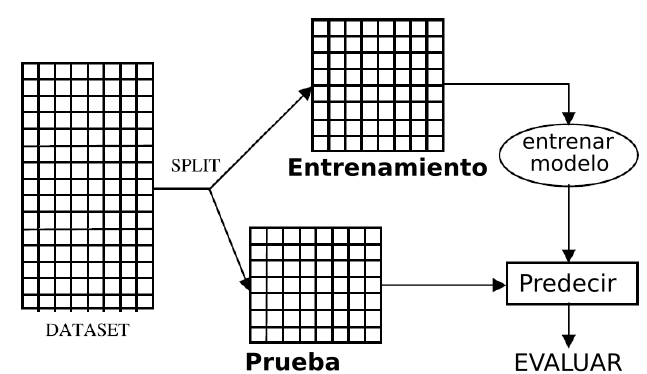

- **Entrenamiento** (80-90%): datos sobre los que se construye/estima el modelo
- **Prueba**(20-10%): se usa el modelo construido para predecir y se evalúa con datos no vistos antes
- ¿Por qué renunciar a parte de los datos si sabemos que un tamaño muestral grande es importante? Evaluar correctamente un modelo lo es mucho más
- La estimación del error en prueba puede ser volátil dependiendo de las observaciones incluidas en cada grupo

## Evaluación de Modelos: Validación cruzada

- Para evitar que los datos sean sensibles a una partición concreta, se usa validación cruzada (*cross-validation* o *rotation estimation*)
- Se repite varias veces y de forma ordenada el proceso de remuestreo para la partición en grupos de entrenamiento y prueba (similar a *bootstrap*)

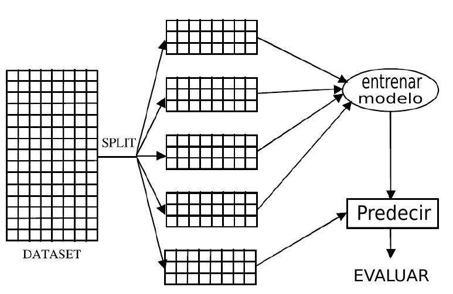

## Validación cruzada de K bloques

- La **validación cruzada de K bloques** divide (aleatoriamente y *ex-ante*) la muestra en K subconjuntos (normalmente 5 o 10)

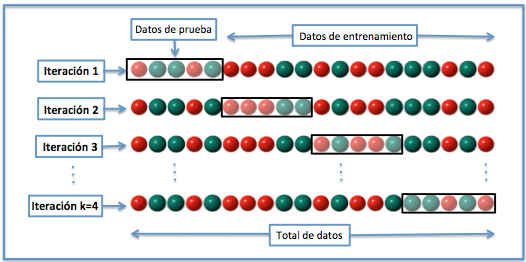

- Un subconjunto se usa como prueba y el K-1 restantes como entrenamiento
- Se repite el proceso durante k iteraciones, con cada posible subconjunto de datos de prueba.
- Se calcula la media aritmética de los resultados de cada iteración para obtener un único resultado
- Es el tipo más habitual de validación cruzada

## Validación cruzada aleatoria (RCV) y LOOCV

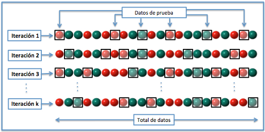

- **RCV**: en *cada iteración* se realiza la particion aleatoria (con reemplazamiento) entre entrenamiento y prueba
- Las observaciones pueden “repetir” como prueba

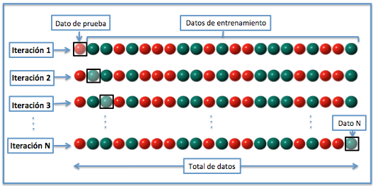

- **LOOCV** (*leave one out CV*): solo una observación se usa como prueba en cada iteración y el resto como entrenamiento
- Se realizan \(n\) iteraciones; se calcula una media sobre \(n\) resultados